# ML Supervised Algorithms

### Group Work

#### Modeling nonlinear relationships in the California Housing dataset

- construct polynomial features to fit nonlinear relationships in the Housing dataset
- model the relationship between house prices and MedInc as using second degree (quadratic) and third degree (cubic) polynomials and compare it to a linear fit
- plot scatter plot between price and MedInc and add all fits in one plot
- report mean_squared_error, r2_score for all fits
- use simple least sqare error regression

```python
# from sklearn.datasets import fetch_california_housing
import pandas as pd
import numpy as np
import seaborn as sns
import matplotlib.pyplot as plt
from sklearn.linear_model import Ridge
from sklearn.pipeline import make_pipeline
from sklearn.preprocessing import PolynomialFeatures , SplineTransformer
from sklearn.linear_model import LinearRegression
from sklearn.metrics import r2_score

# housing = fetch_california_housing
# df= pd.DataFrame(data= np.c_[housing['data'], housing['target']],columns= list(housing['feature_names']) + ['target'])
```

```python
# load housing dataset (saved on your gdrive - check the Dataset folder on Onedrive)

# First mount google drive to be usable and reachable as data storage in colab
#from google.colab import drive
#drive.mount('/content/drive')

# define path to file
#filename = '/content/drive/MyDrive/Teaching/MLP/2024_spring/Datasets/housing.pkl'
filename = './housing.pkl'

# import pickle package to deal with pkl data
import pickle
with open(filename, 'rb') as bunch:
    housing = pickle.load(bunch)

#use c_[] to stack np arrays in axis 1 horizontally (columns)
df= pd.DataFrame(data= np.c_[housing['data'], housing['target']],columns= list(housing['feature_names']) + ['target'])
df
df.info()
#reduce amount of data points for efficiency / simulating train test split
df2 = df.sample(200,random_state=10)
```

```
<class 'pandas.core.frame.DataFrame'>
RangeIndex: 20640 entries, 0 to 20639
Data columns (total 9 columns):
 #   Column      Non-Null Count  Dtype
---  ------      --------------  -----
 0   MedInc      20640 non-null  float64
 1   HouseAge    20640 non-null  float64
 2   AveRooms    20640 non-null  float64
 3   AveBedrms   20640 non-null  float64
 4   Population  20640 non-null  float64
 5   AveOccup    20640 non-null  float64
 6   Latitude    20640 non-null  float64
 7   Longitude   20640 non-null  float64
 8   target      20640 non-null  float64
dtypes: float64(9)
memory usage: 1.4 MB
```

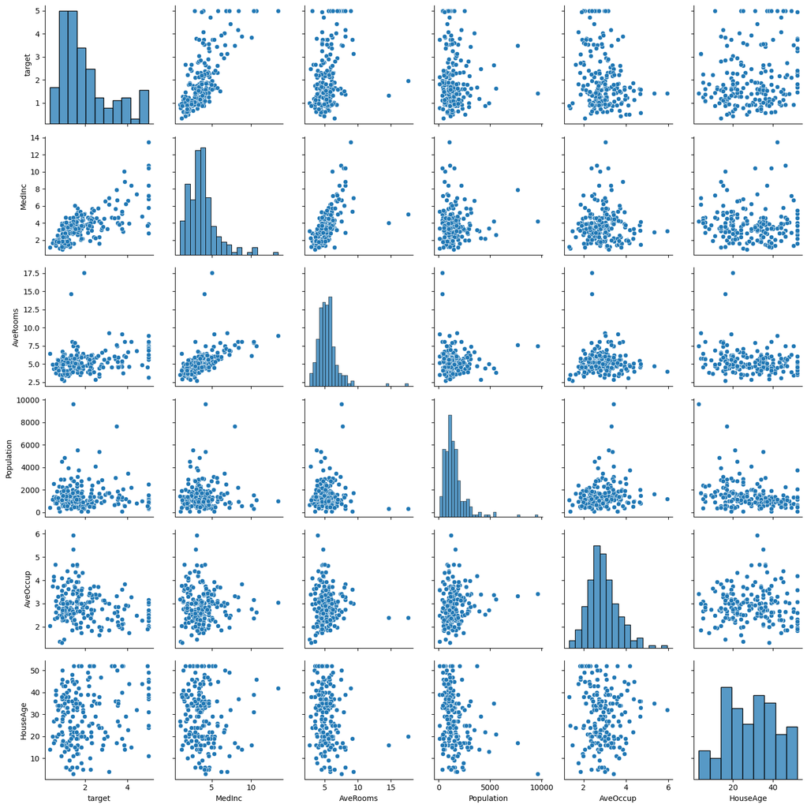

```python
# your code
cols = ['target','MedInc', 'AveRooms', 'Population', 'AveOccup'] + ['HouseAge']
#plot the corellation of each feature using pairplot from seaborn but check all features
sns.pairplot(df2[cols], height=2.5)
plt.tight_layout()
```

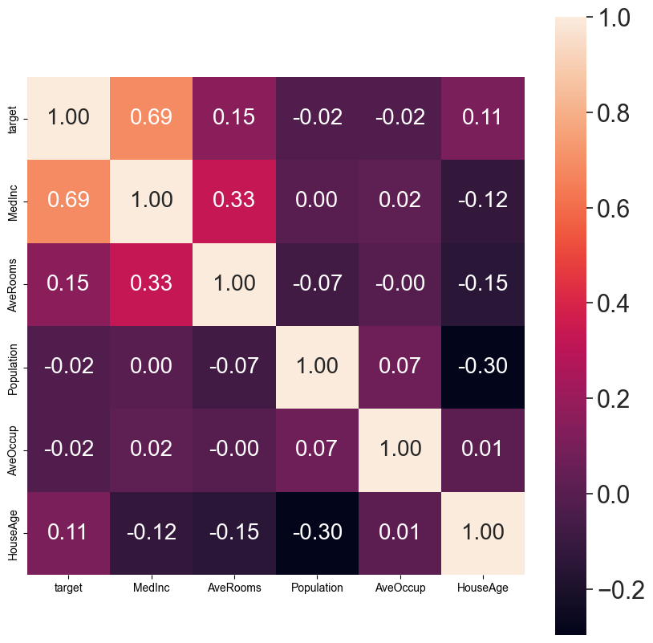

```python
# get correlation matrix to see possible dependencies
cm = np.corrcoef(df[cols].values.T)

fig, ax = plt.subplots(figsize=(10,10))         # Sample figsize in inches

sns.set(font_scale=2)
hm = sns.heatmap(cm, ax=ax, cbar=True, annot=True, square=True, fmt='.2f', annot_kws={'size': 20}, yticklabels=cols, xticklabels=cols)
```

```python
#linear fit
from sklearn import datasets, linear_model
from sklearn.preprocessing import PolynomialFeatures, StandardScaler
from sklearn.metrics import mean_squared_error, r2_score
```

```python
#baseline
# one feature
# X = df.drop(columns='target')
X= df[['MedInc']].values
X2 = df[['MedInc']].values
X3 = df[['MedInc']].values


y = df['target'].values
sc_x = StandardScaler()
sc_y = StandardScaler()

sc_x2 = PolynomialFeatures(degree=2, include_bias=False)
sc_y2 = StandardScaler()

sc_x3 = PolynomialFeatures(degree=3, include_bias=False)
sc_y3 = StandardScaler()

# scaling input and output
X1 = sc_x.fit_transform(X)
X2 = sc_x2.fit_transform(X2)
X3 = sc_x3.fit_transform(X3)


# print(X_std)
y1 = sc_y.fit_transform(y[:, np.newaxis]).flatten()
y2 = sc_y2.fit_transform(y[:,np.newaxis]).flatten() #y[:,np.newaxis].copy() #
y3 = sc_y3.fit_transform(y[:,np.newaxis]).flatten() #y[:,np.newaxis].copy() #

# print(X.shape)

# # Split the data into training/testing sets
X_train = X1[:-100]
X_train2 = X2[:-100]
X_train3 = X3[:-100]
# print(X_train.shape)
X_test = X1[-100:]
X_test2 = X2[-100:]
X_test3 = X3[-100:]
# Split the targets into training/testing sets
y_train = y1[:-100]
y_test = y1[-100:]
y_train2 = y2[:-100]
y_test2 = y2[-100:]
y_train3 = y3[:-100]
y_test3 = y3[-100:]

# Create linear regression object
regr = linear_model.LinearRegression()
regr2 = linear_model.LinearRegression()
regr3 = linear_model.LinearRegression()

# print(X_train.shape)
# Train the model using the training sets
regr.fit(X_train, y_train)
regr2.fit(X_train2,y_train2)
regr3.fit(X_train3,y_train3)

# regr.fit(X_train, y_train)
# # Make predictions using the training set
y_pred = regr.predict(X_train)
y_pred2 = regr2.predict(X_train2)
y_pred3 = regr3.predict(X_train3)
#y=a + bx (b)
# The coefficients
print('Coefficients: \n', regr.coef_)
print('Coefficients: \n', regr2.coef_)
print('Coefficients: \n', regr3.coef_)
#(a)
# The intercept
print('Intercept: \n', regr.intercept_)
print('Intercept: \n', regr2.intercept_)
print('Intercept: \n', regr3.intercept_)

# The mean squared error
print('Mean squared error: %.2f'
      % mean_squared_error(y_train, y_pred))
print('Mean squared error 2nd degree: %.2f'
      % mean_squared_error(y_train2, y_pred2))
print('Mean squared error 3rd degree: %.2f'
      % mean_squared_error(y_train3, y_pred3))

# The coefficient of determination: 1 is perfect prediction
print('Coefficient of determination (aka R2): %.2f'
      % r2_score(y_train, y_pred))
print('Coefficient of determination (aka R2) 2nd degree: %.2f'
      % r2_score(y_train2, y_pred2))
print('Coefficient of determination (aka R2) 3rd degree: %.2f'
      % r2_score(y_train3, y_pred3))


# # Make predictions using the testing set
y_pred = regr.predict(X_test)
# The coefficients
print('Coefficients: \n', regr.coef_)
# The intercept
print('Intercept: \n', regr.intercept_)

# # Make predictions using the testing set
y_pred2 = regr2.predict(X_test2)
# The coefficients
print('Coefficients  2nd degree: \n', regr2.coef_)
# The intercept
print('Intercept  2nd degree: \n', regr2.intercept_)

# # Make predictions using the testing set
y_pred3 = regr3.predict(X_test3)
# The coefficients
print('Coefficients 3rd degree: \n', regr3.coef_)
# The intercept
print('Intercept 3rd degree: \n', regr3.intercept_)

# The mean squared error
print('Mean squared error: %.2f'
      % mean_squared_error(y_test, y_pred))
# The coefficient of determination: 1 is perfect prediction
print('Coefficient of determination (aka R2): %.2f'
      % r2_score(y_test, y_pred))

# The mean squared error
print('Mean squared error 2nd degree: %.2f'
      % mean_squared_error(y_test2, y_pred2))
# The coefficient of determination: 1 is perfect prediction
print('Coefficient of determination (aka R2) 2nd degree: %.2f'
      % r2_score(y_test2, y_pred2))
# The mean squared error
print('Mean squared error 3rd degree: %.2f'
      % mean_squared_error(y_test3, y_pred3))
# The coefficient of determination: 1 is perfect prediction
print('Coefficient of determination (aka R2) 3rd degree: %.2f'
      % r2_score(y_test3, y_pred3))


#results without scaling y (worse):
# Mean squared error 2nd degree: 0.47
# Coefficient of determination (aka R2) 2nd degree: -0.81
# Mean squared error 3rd degree: 0.46
# Coefficient of determination (aka R2) 3rd degree: -0.76
```

```
Coefficients:
 [0.68703256]
Coefficients:
 [ 0.46049225 -0.0090868 ]
Coefficients:
 [ 0.12333807  0.05308163 -0.00307962]
Intercept:
 0.002248132773181232
Intercept:
 -1.611323620404761
Intercept:
 -1.1196563628707652
Mean squared error: 0.53
Mean squared error 2nd degree: 0.52
Mean squared error 3rd degree: 0.51
Coefficient of determination (aka R2): 0.47
Coefficient of determination (aka R2) 2nd degree: 0.48
Coefficient of determination (aka R2) 3rd degree: 0.49
Coefficients:
 [0.68703256]
Intercept:
 0.002248132773181232
Coefficients  2nd degree:
 [ 0.46049225 -0.0090868 ]
Intercept  2nd degree:
 -1.611323620404761
Coefficients 3rd degree:
 [ 0.12333807  0.05308163 -0.00307962]
Intercept 3rd degree:
 -1.1196563628707652
Mean squared error: 0.36
Coefficient of determination (aka R2): -0.84
Mean squared error 2nd degree: 0.35
Coefficient of determination (aka R2) 2nd degree: -0.81
Mean squared error 3rd degree: 0.35
Coefficient of determination (aka R2) 3rd degree: -0.76
```

```python
# R2 Score:   1-((Sum of Square Residuals) / (Sum of Squares))
# Residuals: difference between actual value and predicted value
# Totals (mean) Squares
print(y_test.shape)
print(y_pred.shape)

def r2_score_manual(y_test, y_pred):
    print(len(y_test))
    print(len(y_pred))

    residuals = y_test-y_pred #is correct
    print("difference between second point: %.2f %.2f = %.8f"% (y_test[1],y_pred[1], y_test[1]-y_pred[1]))
    RSS=np.sum(np.square(residuals))
    print(RSS)
    TSS= np.sum(np.square(y_test - np.mean(y_test)) )
    r2_score = 1 - (RSS/ TSS)
    print("r2_score = %.2f" % (r2_score))


r2_score_manual(y_test, y_pred)
```

```
(100,)
(100,)
100
100
difference between second point: 0.17 0.27 = -0.10390117
36.03393909405513
r2_score = -0.84
```

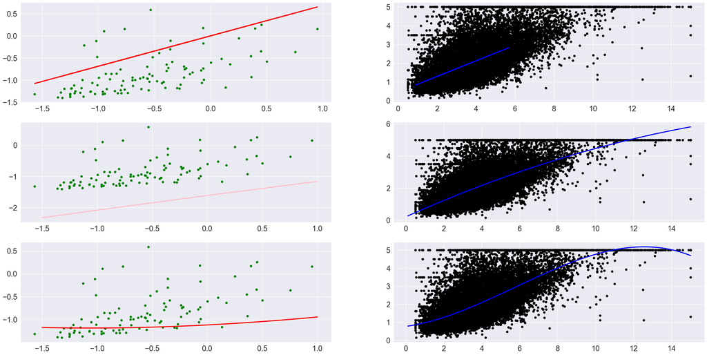

```python
# Plot outputs and check results
fig, ((ax1, ax2), (ax3, ax4), (ax5, ax6)) = plt.subplots(3, 2, figsize=(36, 18))

ax1.plot(X_test, y_pred, color='red', linewidth=3)
ax1.scatter(X_test, y_test,  color='green')


X_test_plot2 = np.linspace(-1.5, 1, 100)
X_test_plot2 = X_test_plot2.reshape(-1,1)
X_test_plot2_t = sc_x2.transform(X_test_plot2)
y_pred_plot2 = regr2.predict(X_test_plot2_t)


X_test_plot3 = np.linspace(-1.5, 1, 100)
X_test_plot3 = X_test_plot3.reshape(-1,1)
X_test_plot3_t = sc_x3.transform(X_test_plot3)
y_pred_plot3 = regr3.predict(X_test_plot3_t)

ax3.plot(X_test_plot2, y_pred_plot2, color='pink', linewidth=3)
ax3.scatter(X_test, y_test2,  color='green')

ax5.plot(X_test_plot3, y_pred_plot3, color='red', linewidth=3)
ax5.scatter(X_test, y_test3,  color='green')



X_inv = X1.reshape(-1, 1)
y_inv = y1.reshape(-1, 1)
X_test_inv = X_test.reshape(-1, 1)
y_pred_inv = y_pred.reshape(-1, 1)
X_inv = sc_x.inverse_transform(X_inv)
y_inv = sc_y.inverse_transform(y_inv)
X_test_inv = sc_x.inverse_transform(X_test_inv)
y_pred_inv = sc_y.inverse_transform(y_pred_inv)

X_test_inv2 = np.linspace(.1, 15, 100)
X_test_inv2 = X_test_inv2.reshape(-1,1)
X_test_inv2_t = sc_x2.transform(X_test_inv2)
y_pred_inv2 = regr2.predict(X_test_inv2_t)
y_pred_inv2 = sc_y2.inverse_transform(y_pred_inv2.reshape(-1,1))

X_test_inv3 = np.linspace(.1, 15, 100)
X_test_inv3 = X_test_inv3.reshape(-1,1)
X_test_inv3_t = sc_x3.transform(X_test_inv3)
y_pred_inv3 = regr3.predict(X_test_inv3_t)
y_pred_inv3 = sc_y3.inverse_transform(y_pred_inv3.reshape(-1,1))

ax2.scatter(X_inv, y_inv,  color='black')
ax2.plot(X_test_inv, y_pred_inv, color='blue', linewidth=3)

ax4.scatter(X_inv, y_inv,  color='black')
ax4.plot(X_test_inv2, y_pred_inv2, color='blue', linewidth=3)

ax6.scatter(X_inv, y_inv,  color='black')
ax6.plot(X_test_inv3, y_pred_inv3, color='blue', linewidth=3)

plt.show()
```

```
[-0.28571941  0.28051781  0.32576054 -0.76305149 -0.66572915 -0.07495893
 -0.18655568 -0.62646643 -0.85286449 -0.07398044 -0.39547118 -0.46802359
 -0.19520604 -0.42338481 -0.69163738 -0.28693362 -0.6998439  -0.57766491
  0.25144458  0.32215952  0.04820504 -0.59919711 -0.41349967 -0.30983212
 -0.39483606 -0.55503275  0.16727557  0.56934338  0.36428347  0.1064387
 -0.27414037 -0.20069583 -0.42613652  0.72867456 -0.70523605 -0.07308002
 -0.200658   -0.51177989 -0.40680371 -0.69839611 -0.41300954 -0.29945022
 -0.0701817  -0.02385688 -0.22759536 -0.33756588 -0.42731975 -0.82014694
 -0.67105437 -0.78130405 -0.7761301  -0.82702178 -0.9694207  -0.22237612
 -0.08285667 -0.36768679 -0.46152771 -0.65168112 -0.71124842 -0.80369222
 -0.317884   -0.80725274 -0.82338114 -0.86710204 -0.57676418 -0.73347815
 -0.66117398 -0.7318119  -0.7670676  -0.59229612 -0.86070602 -0.87988038
 -0.82733537 -0.82670808 -0.53773764 -0.57347882 -0.67120535 -0.24447053
 -0.6084987  -0.44988725  0.25555585 -0.57144637 -0.55503275 -0.41755676
 -0.32841361  0.07617342 -0.63454845 -0.3550572  -0.49588941 -0.6568172
 -0.14397817 -0.16292219 -0.30983212 -0.51121226 -0.08773626 -0.80968102
 -0.50877286 -0.77170583 -0.72434169 -0.56416742]
```

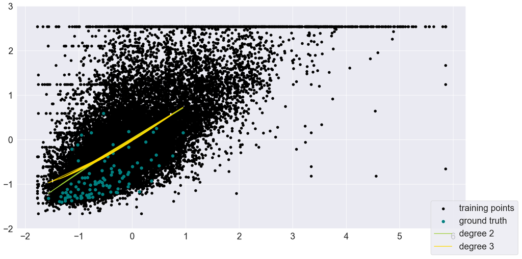

```python
# plot function
lw = 2
fig, ax = plt.subplots()
ax.set_prop_cycle(
    color=["black", "teal", "yellowgreen", "gold", "darkorange", "tomato"]
)
# plot training points
ax.scatter(X_train, y_train, label="training points", color="black")

ax.scatter(X_test, y_test, linewidth=lw, label="ground truth", color="teal")




# polynomial features
#for degree in [2, 3]:
model = make_pipeline(PolynomialFeatures(degree=2), Ridge(alpha=1e-3))
model.fit(X_train, y_train)
y_plot = model.predict(X_test)

ax.plot(X_test, y_plot, label=f"degree 2", color="yellowgreen")


model = make_pipeline(PolynomialFeatures(degree=3), Ridge(alpha=1e-3))
model.fit(X_train, y_train)
y_plot = model.predict(X_test)

ax.plot(X_test, y_plot, label=f"degree 3", color="gold")

print(y_plot)
# B-spline with 4 + 3 - 1 = 6 basis functions
# model = make_pipeline(SplineTransformer(n_knots=4, degree=3), Ridge(alpha=1e-3))
# model.fit(X_train, y_train)

#y_plot = model.predict(X_plot)
#ax.plot(x_plot, y_plot, label="B-spline")
fig.set_size_inches((20,10))
fig.legend(loc="outside lower right")
ax.set_ylim(-2, 3)
plt.show()
```

```python
# predict from MedInc
# first get proper input format
MedInc = [[3]]
MedInc_std = sc_x.transform(MedInc)
p = regr.predict(MedInc_std)
p = p.reshape(-1, 1)
p_inv_transform = sc_y.inverse_transform(p)
print('price for income median equal', *MedInc[0], 'is', p_inv_transform[0])
```

```
price for income median equal 3 is [1.70781683]
```

## Homework

### 1

Apply a regression algorithm to selected toy data (housing, diabetes, ...). You can generate your own dataset with sklearn.datasets.make_regression

Select two different feature sets and compare results.

- Use one of these:
  - sklearn.tree.DecisionTreeRegressor
  - sklearn.ensemble.RandomForestRegressor
  - sklearn.svm.SVR
- Use feature engineering to generate new features or to drop less significant features

```python
# your code
from sklearn.datasets import load_diabetes
import sklearn.ensemble._forest as forest
import seaborn as sns
import pandas as pd
import numpy as np
import matplotlib.pyplot as plt

diabetes = load_diabetes()
cols=(diabetes.feature_names)

# s1 (total serum cholesterol)
# s2 (low-density lipoproteins)
# s3 (high-density lipoproteins)
# s4 (total cholesterol / HDL)
# s5 (possibly log of serum triglycerides)
# s6 (blood sugar)

df= pd.DataFrame(data= np.c_[diabetes['data'], diabetes['target']],columns= cols + ['target'])
df2 = df.sample(200,random_state=10)

df.shape
```

```
(442, 11)
```

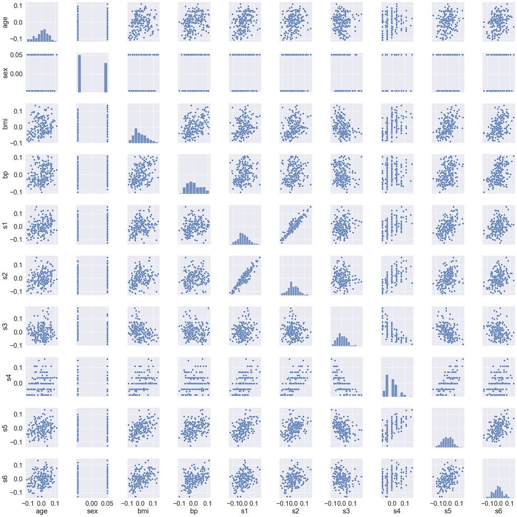

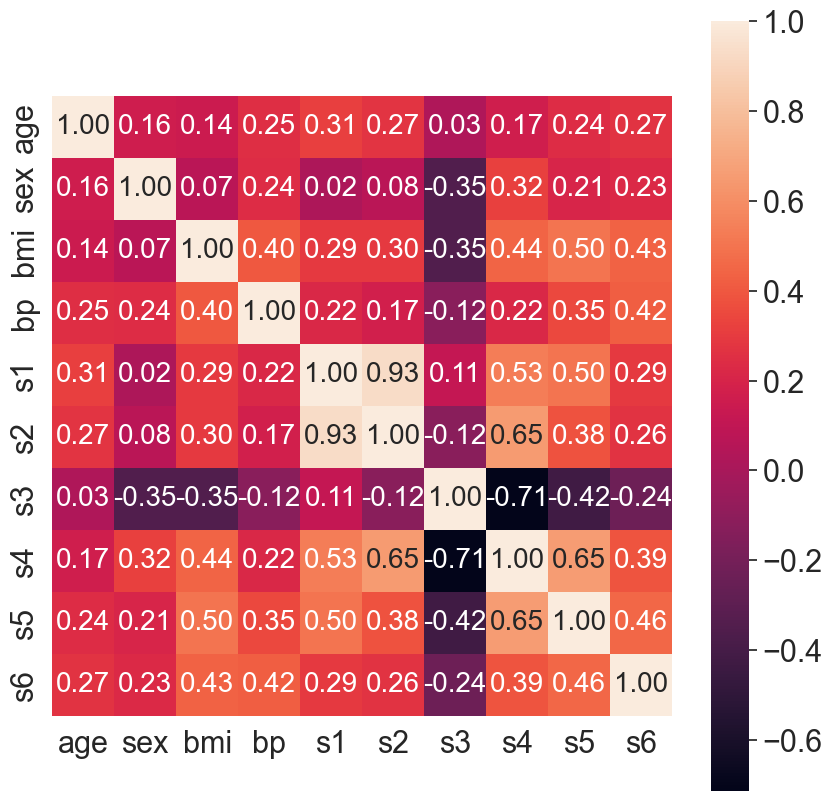

```python
sns.pairplot(df2[cols], height=2.5)
plt.tight_layout()


# get correlation matrix to see possible dependencies
cm = np.corrcoef(df2[cols].values.T)

fig, ax = plt.subplots(figsize=(10,10))         # Sample figsize in inches

sns.set(font_scale=2)
hm = sns.heatmap(cm, ax=ax, cbar=True, annot=True, square=True, fmt='.2f', annot_kws={'size': 20}, yticklabels=cols, xticklabels=cols)
```

```python
RFModel1 = forest.RandomForestRegressor(max_depth=3, random_state=0)
RFModel2 = forest.RandomForestRegressor(max_depth=4, random_state=0)

#Set 1
cols1=['age','sex','s1','s2','s3','s4','s5','s6']
X1 = df[cols1].values
#Set 2
cols2 = ['bmi','bp','s1','s2','s3','s4','s5','s6']
X2 = df[cols2].values
#ground truth
y = df['target'].values

# # Split the data into training/testing sets
X_train1 = X1[:-100]
X_train2 = X2[:-100]

X_test1 = X1[-100:]
X_test2 = X2[-100:]

# Split the targets into training/testing sets
y_train = y[:-100]
y_test = y[-100:]


RFModel1.fit(X=X_train1,y=y_train)
RFModel2.fit(X=X_train2,y=y_train)

y_pred1 = RFModel1.predict(X_test1)
y_pred2 = RFModel2.predict(X_test2)


print("Score 1: %.5f" % RFModel1.score(X_test1,y_test))

print("Score 2: %.5f" % RFModel2.score(X_test2,y_test))

importance = RFModel1.feature_importances_
print(len(importance),  ' predictive attributes/features')

for i,v in enumerate(importance):
	print('Feature: %0s, Score: %.5f' % (df[cols1].columns[i],v))
# plt.bar([x for x in range(len(importance))], importance)
importance2 = RFModel2.feature_importances_
print(len(importance2),  ' predictive attributes/features')

for i,v in enumerate(importance2):
	print('Feature: %0s, Score: %.5f' % (df[cols2].columns[i],v))
# plt.bar([x for x in range(len(importance))], importance)

fig, axes = plt.subplots( figsize=(15, 10))
model_color = ["m", "c", "g"]

print(X_test1.shape)
print(y_test.shape)
axes.scatter(
    y_test,
    y_test,
    color=model_color[0],
    label="ground truth")
axes.scatter(
    y_test,
    y_pred1,
    color=model_color[1],
    label="prediction feature set 1")
axes.scatter(
    y_test,
    y_pred2,
    color=model_color[2],
    label="prediction feature set 2")


fig.legend(
    loc="upper right",
    bbox_to_anchor=(1.5, 1.1),
    ncol=1,
    fancybox=True,
    shadow=True,
)

fig.text(0.5, 0.04, "data", ha="center", va="center")
fig.text(0.06, 0.5, "target", ha="center", va="center", rotation="vertical")
fig.suptitle("Random Forest Regression", fontsize=14)
plt.show()
```

[output not shown]

```python
from sklearn.svm import SVR
from sklearn.pipeline import make_pipeline
from sklearn.preprocessing import StandardScaler
import numpy as np
#Set 2
cols2 = ['bmi','bp','s1','s2','s3','s4','s5','s6']
X2 = df[cols2].values
x2_sc = StandardScaler()

X2 = x2_sc.fit_transform(X2)
#ground truth

y_sc = StandardScaler()
y = df['target'].values
y= y_sc.fit_transform(y.reshape(-1,1))

# # Split the data into training/testing sets
X_train2 = X2[:-100]
X_test2 = X2[-100:]

# Split the targets into training/testing sets
y_train = y[:-100]
y_test = y[-100:]



svr = SVR(kernel="linear", C=1.0, epsilon=0.2,gamma="auto")# make_pipeline(StandardScaler(), SVR(kernel="linear", C=1.0, epsilon=0.2,gamma="auto"))
svr3 = SVR(kernel="poly", C=1.0, epsilon=0.2, gamma="auto", degree=3, coef0=1)# make_pipeline(StandardScaler(), SVR(kernel="poly", C=1.0, epsilon=0.2, gamma="auto", degree=3, coef0=1))
svr4 = SVR(kernel="rbf", C=1.0, epsilon=0.2)#make_pipeline(StandardScaler(), SVR(kernel="rbf", C=1.0, epsilon=0.2))

svr.fit(X_train2, y_train)
print("Accuracy on training set linear: {:.2f}".format(svr.score(X_test2, y_test)))
svr3.fit(X_train2, y_train)
print("Accuracy on training set poly 3rd degree: {:.2f}".format(svr3.score(X_test2, y_test)))
svr4.fit(X_train2,y_train)
print("Accuracy on training set rbf: {:.2f}".format(svr4.score(X_test2, y_test)))

y_pred = svr.predict(X_test2)
y_pred3 = svr3.predict(X_test2)
y_pred4 = svr4.predict(X_test2)

y_pred = y_sc.inverse_transform(y_pred)
y_pred3 = y_sc.inverse_transform(y_pred3)
y_pred4 = y_sc.inverse_transform(y_pred4)

lw = 2
kernel_label = [ "Linear", "Polynomial","RBF"]
model_color = ["m", "c", "g"]

fig, axes = plt.subplots(nrows=1, ncols=3, figsize=(15, 10), sharey=True)

axes[0].scatter(
    X_test2,
    y_test,
    lw=lw
)
axes[0].plot(
    X_test2,
    y_pred,
    color=model_color[0],
    lw=lw,
    label="{} model".format(kernel_label[0]),
)
axes[1].scatter(
    X_test2,
    y_test,
    lw=lw
)
axes[1].plot(
    X_test2,
    y_pred3,
    color=model_color[1],
    lw=lw,
    label="{} model".format(kernel_label[1]),
)
axes[2].scatter(
    X_test2,
    y_test,
    lw=lw
)
axes[2].plot(
    X_test2,
    y_pred4,
    color=model_color[2],
    lw=lw,
    label="{} model".format(kernel_label[2]),
)
fig.legend(
    loc="upper center",
    bbox_to_anchor=(1.5, 1.1),
    ncol=1,
    fancybox=True,
    shadow=True,
)

fig.text(0.5, 0.04, "data", ha="center", va="center")
fig.text(0.06, 0.5, "target", ha="center", va="center", rotation="vertical")
fig.suptitle("Support Vector Regression", fontsize=14)
plt.show()
```

```
Accuracy on training set linear: 0.53
Accuracy on training set poly 3rd degree: 0.36
Accuracy on training set rbf: 0.47
```

[output not shown]

### 2

Apply a classification algorithm to iris data to classify 3 classes of flowers. Use logistic regression, SVC with linear and rbf kernel, KNN, and decision tree Compare results in terms of prediction accuracy within training and testing data

```python
# your code
from sklearn import datasets

iris = datasets.load_iris()
df= pd.DataFrame(data= np.c_[iris['data'], iris['target']],columns= list(iris['feature_names']) + ['target'])
df
```

|  | sepal length (cm) | sepal width (cm) | petal length (cm) | petal width (cm) | target |
| --- | --- | --- | --- | --- | --- |
| 0 | 5.1 | 3.5 | 1.4 | 0.2 | 0.0 |
| 1 | 4.9 | 3.0 | 1.4 | 0.2 | 0.0 |
| 2 | 4.7 | 3.2 | 1.3 | 0.2 | 0.0 |
| 3 | 4.6 | 3.1 | 1.5 | 0.2 | 0.0 |
| 4 | 5.0 | 3.6 | 1.4 | 0.2 | 0.0 |
| ... | ... | ... | ... | ... | ... |
| 145 | 6.7 | 3.0 | 5.2 | 2.3 | 2.0 |
| 146 | 6.3 | 2.5 | 5.0 | 1.9 | 2.0 |
| 147 | 6.5 | 3.0 | 5.2 | 2.0 | 2.0 |
| 148 | 6.2 | 3.4 | 5.4 | 2.3 | 2.0 |
| 149 | 5.9 | 3.0 | 5.1 | 1.8 | 2.0 |

150 rows × 5 columns

```python
from sklearn.linear_model import LogisticRegression

# iris

X = df[['sepal length (cm)','sepal width (cm)']]  # we only take the first two features for displaying purposes here
y = df['target']

print(X.shape, y.shape)
# Create an instance of Logistic Regression Classifier and fit the data.
logreg = LogisticRegression()
logreg.fit(X, y)

logreg.score(X, y)

# check what happens when another features are used
```

```
(150, 2) (150,)
```

```
0.82
```

```
       sepal length (cm)  sepal width (cm)
0                   3.80               1.5
1                   3.82               1.5
2                   3.84               1.5
3                   3.86               1.5
4                   3.88               1.5
...                  ...               ...
39496               8.32               4.9
39497               8.34               4.9
39498               8.36               4.9
39499               8.38               4.9
39500               8.40               4.9

[39501 rows x 2 columns]
```

```
([], [])
```

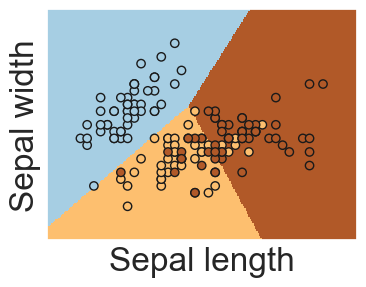

```python
# Plot the decision boundary. For that, we will assign a color to each
# point in the mesh [x_min, x_max]x[y_min, y_max].
x_min, x_max = X.values[:, 0].min() - .5, X.values[:, 0].max() + .5
y_min, y_max = X.values[:, 1].min() - .5, X.values[:, 1].max() + .5
h = .02  # step size in the mesh
xx, yy = np.meshgrid(np.arange(x_min, x_max, h), np.arange(y_min, y_max, h))

data = pd.DataFrame(np.c_[xx.ravel(), yy.ravel()])
data.columns = ['sepal length (cm)','sepal width (cm)']
print(data)
Z = logreg.predict(data)

# Put the result into a color plot
Z = Z.reshape(xx.shape)
plt.figure(1, figsize=(4, 3))
plt.pcolormesh(xx, yy, Z, cmap=plt.cm.Paired)


# Plot also the training points
plt.scatter(X.values[:, 0], X.values[:, 1], c=y, edgecolors='k', cmap=plt.cm.Paired)
plt.xlabel('Sepal length')
plt.ylabel('Sepal width')
plt.xlim(xx.min(), xx.max())
plt.ylim(yy.min(), yy.max())
plt.xticks(())
plt.yticks(())
```

```python
print(xx)
print(yy)
print(np.c_[xx.ravel(), yy.ravel()])
```

```
[[3.8  3.82 3.84 ... 8.36 8.38 8.4 ]
 [3.8  3.82 3.84 ... 8.36 8.38 8.4 ]
 [3.8  3.82 3.84 ... 8.36 8.38 8.4 ]
 ...
 [3.8  3.82 3.84 ... 8.36 8.38 8.4 ]
 [3.8  3.82 3.84 ... 8.36 8.38 8.4 ]
 [3.8  3.82 3.84 ... 8.36 8.38 8.4 ]]
[[1.5  1.5  1.5  ... 1.5  1.5  1.5 ]
 [1.52 1.52 1.52 ... 1.52 1.52 1.52]
 [1.54 1.54 1.54 ... 1.54 1.54 1.54]
 ...
 [4.86 4.86 4.86 ... 4.86 4.86 4.86]
 [4.88 4.88 4.88 ... 4.88 4.88 4.88]
 [4.9  4.9  4.9  ... 4.9  4.9  4.9 ]]
[[3.8  1.5 ]
 [3.82 1.5 ]
 [3.84 1.5 ]
 ...
 [8.36 4.9 ]
 [8.38 4.9 ]
 [8.4  4.9 ]]
```

```python
from sklearn.svm import SVC
svc = SVC(kernel='linear')
svc.fit(X, y)
print("Accuracy on training set: {:.2f}".format(svc.score(X, y)))
# print("Accuracy on test set: {:.2f}".format(svc.score(X, y)))
```

```
Accuracy on training set: 0.82
```

```python
svc.coef_
```

```
array([[-2.22720466,  2.24959915],
       [-2.06931629,  1.72277136],
       [-1.60096201, -0.79648515]])
```

```python
svc = SVC(kernel='rbf', C=1, gamma=10)
svc.fit(X, y)
print("Accuracy on training set: {:.2f}".format(svc.score(X, y)))
print("Accuracy on test set: {:.2f}".format(svc.score(X, y)))

# coef_ parameter = weights assigned to the features (coefficients in the primal problem). Only available in the case of a linear kernel.
```

```
Accuracy on training set: 0.84
Accuracy on test set: 0.84
```

```python
svc.score(X, y)
```

```
0.84
```

```python
from sklearn.tree import DecisionTreeClassifier
from sklearn.model_selection import train_test_split
from sklearn.datasets import load_breast_cancer
import pandas as pd
cancer = load_breast_cancer()


# print(cancer.DESCR)
df= pd.DataFrame(data= np.c_[cancer['data'], cancer['target']],columns= list(cancer['feature_names']) + ['target'])

X_train, X_test, y_train, y_test = train_test_split(cancer.data, cancer.target, stratify=cancer.target, random_state=42) # stratify preserves the class ratios
tree = DecisionTreeClassifier(random_state=0)
tree.fit(X_train, y_train)
print("Accuracy on training set: {:.3f}".format(tree.score(X_train, y_train)))
print("Accuracy on test set: {:.3f}".format(tree.score(X_test, y_test)))
# df
# overfitting because of full tree with pure leaves
```

```
Accuracy on training set: 1.000
Accuracy on test set: 0.937
```

```python
tree = DecisionTreeClassifier(max_depth=4, random_state=0)
tree.fit(X_train, y_train)
print("Accuracy on training set: {:.3f}".format(tree.score(X_train, y_train)))
print("Accuracy on test set: {:.3f}".format(tree.score(X_test, y_test)))
```

```
Accuracy on training set: 0.988
Accuracy on test set: 0.951
```

```python
import graphviz
from IPython.display import Image

with open("tree.dot") as f:
  dot_graph = f.read()
graph = graphviz.Source(dot_graph)
graph.render("tree", format="png", cleanup=True)
Image("tree.png")
```

```
Error: tree: syntax error in line 4
```

[output not shown]

[output cut: 11 more lines]

[output not shown]

```python
importance = tree.feature_importances_
print(len(importance),  ' predictive attributes/features')

for i,v in enumerate(importance):
	print('Feature: %0s, Score: %.5f' % (df.columns[i],v))
# plt.bar([x for x in range(len(importance))], importance)
```

```
30  predictive attributes/features
Feature: mean radius, Score: 0.00000
Feature: mean texture, Score: 0.00000
Feature: mean perimeter, Score: 0.00000
Feature: mean area, Score: 0.00000
Feature: mean smoothness, Score: 0.00000
Feature: mean compactness, Score: 0.00000
Feature: mean concavity, Score: 0.00000
Feature: mean concave points, Score: 0.00000
Feature: mean symmetry, Score: 0.00000
Feature: mean fractal dimension, Score: 0.00000
Feature: radius error, Score: 0.01020
Feature: texture error, Score: 0.04840
Feature: perimeter error, Score: 0.00000
Feature: area error, Score: 0.00000
Feature: smoothness error, Score: 0.00242
Feature: compactness error, Score: 0.00000
Feature: concavity error, Score: 0.00000
Feature: concave points error, Score: 0.00000
Feature: symmetry error, Score: 0.00000
Feature: fractal dimension error, Score: 0.00000
Feature: worst radius, Score: 0.72683
Feature: worst texture, Score: 0.04582
Feature: worst perimeter, Score: 0.00000
Feature: worst area, Score: 0.00000
Feature: worst smoothness, Score: 0.01416
Feature: worst compactness, Score: 0.00000
Feature: worst concavity, Score: 0.01819
Feature: worst concave points, Score: 0.12211
Feature: worst symmetry, Score: 0.01189
Feature: worst fractal dimension, Score: 0.00000
```

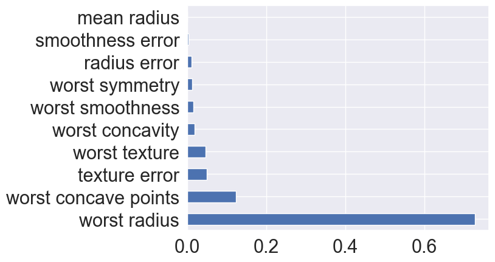

```python
# plot with feature names
s = pd.Series(importance, index=df.columns[:-1]).nlargest(10).plot(kind='barh')
```

```python
from sklearn.ensemble import RandomForestClassifier
X_train, X_test, y_train, y_test = train_test_split(cancer.data, cancer.target, random_state=7)

forest = RandomForestClassifier(n_estimators=5, random_state=0)
forest.fit(X_train, y_train)
print("Accuracy on training set: {:.3f}".format(forest.score(X_train, y_train)))
print("Accuracy on test set: {:.3f}".format(forest.score(X_test, y_test)))

forest = RandomForestClassifier(n_estimators=100, max_depth=4, random_state=0)
forest.fit(X_train, y_train)
print("Accuracy on training set: {:.3f}".format(forest.score(X_train, y_train)))
print("Accuracy on test set: {:.3f}".format(forest.score(X_test, y_test)))

forest.feature_importances_
```

```
Accuracy on training set: 0.995
Accuracy on test set: 0.958
Accuracy on training set: 0.991
Accuracy on test set: 0.972
```

```
array([0.03375728, 0.01357815, 0.05378484, 0.03536351, 0.00507722,
       0.00389859, 0.08387652, 0.07256357, 0.00153227, 0.00191283,
       0.02200079, 0.00213545, 0.01249127, 0.03139741, 0.00318609,
       0.00255546, 0.00299522, 0.00701629, 0.00321919, 0.00343266,
       0.13023684, 0.01356881, 0.18115919, 0.07829777, 0.01028316,
       0.01009687, 0.03560736, 0.1310055 , 0.00810955, 0.00586037])
```

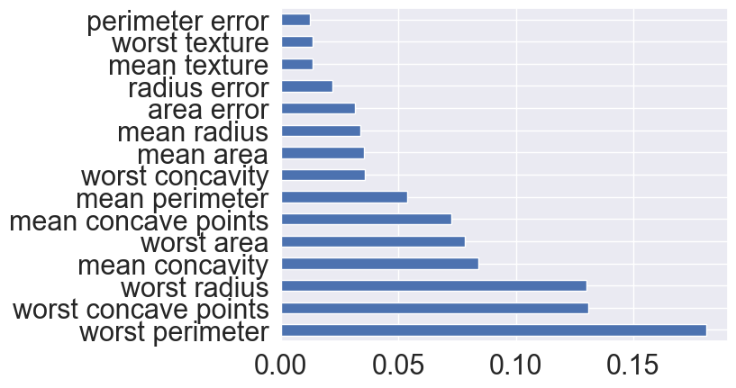

```python
importance = forest.feature_importances_
s = pd.Series(importance, index=df.columns[:-1]).nlargest(15).plot(kind='barh')
```

```python
from sklearn.datasets import load_iris
from sklearn.linear_model import LogisticRegression

iris = load_iris()
X_train, X_test, y_train, y_test = train_test_split(iris.data, iris.target, random_state=42)

logreg = LogisticRegression(C=1e5, max_iter=1000)
logreg.fit(X_train, y_train)

print("Decision function shape: {}".format(logreg.decision_function(X_test).shape))
# plot the first few entries of the decision function
print("Decision function:\n{}".format(logreg.decision_function(X_test)[:6, :]))

# Decision_function has the shape (n_samples, n_classes) and each column provides confidence scores for each class.
# The confidence score for a sample is proportional to the signed distance of that sample to the hyperplane.
```

```
Decision function shape: (38, 3)
Decision function:
[[-15.94706004  12.47991238   3.46714766]
 [ 44.16158212   5.1358679  -49.29745003]
 [-50.84035159  12.89819752  37.94215406]
 [-14.48193207  10.35797684   4.12395523]
 [-15.351015    10.8874788    4.4635362 ]
 [ 40.64973975   5.21841439 -45.86815415]]
```

```python
# show the first few entries of predict_proba
print("Predicted probabilities:\n{}".format(logreg.predict_proba(X_test)[:6]))
# show that sums across rows are one
print("Sums: {}".format(logreg.predict_proba(X_test)[:6].sum(axis=1)))
```

```
Predicted probabilities:
[[4.51096886e-13 9.99878170e-01 1.21829680e-04]
 [1.00000000e+00 1.12550560e-17 2.57785243e-41]
 [2.76852026e-39 1.32907004e-11 1.00000000e+00]
 [1.62672289e-11 9.98042293e-01 1.95770730e-03]
 [4.01849071e-12 9.98380380e-01 1.61962032e-03]
 [1.00000000e+00 4.09610338e-16 2.66536133e-38]]
Sums: [1. 1. 1. 1. 1. 1.]
```

```python
# We can again recover the predictions by computing the argmax of predict_proba:
print("Argmax of predicted probabilities:\n{}".format(
np.argmax(logreg.predict_proba(X_test), axis=1)))
print("Predictions:\n{}".format(logreg.predict(X_test)))
```

```
Argmax of predicted probabilities:
[1 0 2 1 1 0 1 2 1 1 2 0 0 0 0 1 2 1 1 2 0 2 0 2 2 2 2 2 0 0 0 0 1 0 0 2 1
 0]
Predictions:
[1 0 2 1 1 0 1 2 1 1 2 0 0 0 0 1 2 1 1 2 0 2 0 2 2 2 2 2 0 0 0 0 1 0 0 2 1
 0]
```

```python
from sklearn.neighbors import KNeighborsClassifier, KNeighborsRegressor
# https://scikit-learn.org/stable/modules/generated/sklearn.neighbors.KNeighborsClassifier.html?highlight=knei#sklearn.neighbors.KNeighborsClassifier
# https://scikit-learn.org/stable/modules/generated/sklearn.neighbors.KNeighborsRegressor.html?highlight=knei#sklearn.neighbors.KNeighborsRegressor
```

```python
df= pd.DataFrame(data= np.c_[cancer['data'], cancer['target']],columns= list(cancer['feature_names']) + ['target'])

X_train, X_test, y_train, y_test = train_test_split(cancer.data, cancer.target, stratify=cancer.target, random_state=66) # stratify preserves the class ratios
clf = KNeighborsClassifier(n_neighbors=6)
clf.fit(X_train, y_train)
print("Test set predictions: {}".format(clf.predict(X_test)))
print("Test set accuracy: {:.2f}".format(clf.score(X_test, y_test)))
```

```
Test set predictions: [1 1 1 1 1 1 1 1 0 0 0 1 0 1 1 0 1 1 1 1 1 1 1 1 0 1 1 0 1 0 0 0 1 0 0 1 0
 1 1 0 1 0 1 1 1 0 1 1 0 1 1 0 1 1 1 1 0 1 1 1 0 1 0 0 1 1 1 1 0 0 0 0 1 0
 1 0 1 1 1 1 0 0 0 0 1 1 1 1 0 1 1 1 1 0 0 1 1 1 1 0 1 1 1 1 0 1 0 1 1 1 1
 0 0 0 1 1 1 0 0 1 1 0 0 0 0 0 1 0 0 1 1 0 1 0 1 1 1 1 1 1 1 1 1]
Test set accuracy: 0.94
```

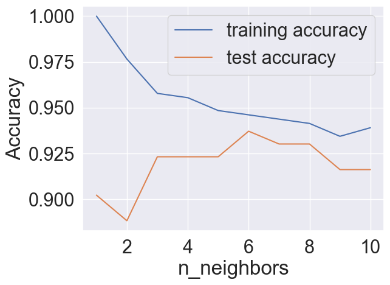

```python
X_train, X_test, y_train, y_test = train_test_split(
cancer.data, cancer.target, stratify=cancer.target, random_state=66)
training_accuracy = []
test_accuracy = []
# try n_neighbors from 1 to 10
neighbors_settings = range(1, 11)
for n_neighbors in neighbors_settings:
  # build the model
  clf = KNeighborsClassifier(n_neighbors=n_neighbors)
  clf.fit(X_train, y_train)
  # record training set accuracy
  training_accuracy.append(clf.score(X_train, y_train))
  # record generalization accuracy
  test_accuracy.append(clf.score(X_test, y_test))
plt.plot(neighbors_settings, training_accuracy, label="training accuracy")
plt.plot(neighbors_settings, test_accuracy, label="test accuracy")
plt.ylabel("Accuracy")
plt.xlabel("n_neighbors")
plt.legend()
```

```python
!jupyter-nbconvert --to html "H:\Documents\My Training\CAS\CAS_DLS\0_Module\M3_Machine_Learning\Notebooks\W2\W2-Exercises.ipynb"
```

[output not shown]

[output cut: 135 more lines]

[output not shown]

```
[NbConvertApp] WARNING | pattern '.\\0_Module\\M3_Machine_Learning\\Notebooks\\W2\\W2-Exercises.ipynb' matched no files
```